# Investigating Drought Climatic Aspects In Puerto Rican Tropical Rainforest

Trung Dam

2023-08-17

# Introduction

# Hypothesis

Our hypothesis is there is a positive correlation between low daily rainfall and high heat shock. In higher elevation area of Luquillo Mountains (Bisley Experimental Watersheds), the occurrences of a low rainfall day combined with high temperature tend to be lower compared to lower elevated area (Sabana Field Research Station). As a consequence, Sabana Field Research Station’s biodiversity would increase after the major drought and decrease substantially after hurricanes.

# Data and Methods

## Data Description

1. Weather data

The data got loaded and processed in R. We reformatted the timestamp and date for future time series use. NAs, outliers were removed from the data. Temperature values, which are negative or greater than 50 C°, were eliminated. Relative humidity values had to be greater or equal to 63% (SK Brown, 1983). Daily rainfall values that are more than 400 mm were eliminated as the maximum daily rainfall in Sabana Field Research Station was claimed to be 310 mm (SK Brown, 1983). In addition, some of the data were missing because of an electricity shortage during Hurricane Maria and Irma (August - December 2017). We calculated the daily heat index, a measure of the combined effects of temperature and relative humidity. Daily heat intensity was classified according to the Heat Index Chart from the National Weather Service, including four intensity levels: Hot, Extreme Hot, Danger Hot, Extreme Danger Hot. Furthermore, daily rainfall intensity (Low rainfall and High rainfall) was identified by comparing to a threshold, which is the first percentile of the rolling averages of respectively two study sites (0.1 mm). Climate stressors variable was categorized as day with “Low rainfall” and “Danger Hot” or “Extreme Danger Hot”. This variable was further integrated in our statistical test to clarify the impact of drought on Sabana Field Research Station’s biodiversity.

2. TRACE Seedling and Sapling Census data

The seedling and sapling census data is collected in Sabana Field Research Station by Tropical Responses to Altered Climate Experiment (TRACE) from 2015 to 2018. The data contains one seedling & sapling census each year except for 2015. There were two censuses that year: one was recorded during the major drought and the other was recorded after. All the seedlings and saplings measured are in the hexagon plots, which cover approximately 12 square meters. They scatter in 6 different plots across topography in the study site. 3 of them are control plots whereas the others are warming plots (4 ° C more than ambient temperature). The data sets contain month stamps, type classification, species classification, height (in cm), diameter (in mm), number of leaves, and damage estimation (in %).

The data got loaded and processed in R. We calculated Shannon D’s biodiversity index of Sabana Field Research Station’s ecosystem over time. This was later used for observing the changes in the plant’s decomposition after the major drought in 2015. The percentage of changes of each plant over time were computed to clarify top drought-resistant plants.

## Statistical Testing

The meterological data are fit in a linear model to explore the relationship between rainfall and temperature change in two study sites: Sabana Field Research Station and Bisley Experimental Watersheds. The data sets further got fitted in a logistic model to investigate the probability of having a “climatic stressors” day (a day with low rainfall and extreme heat) in regard to daily temperature, daily precipitation, and different topography.

## Data exploratory analyses

### Sabana Field Research Station

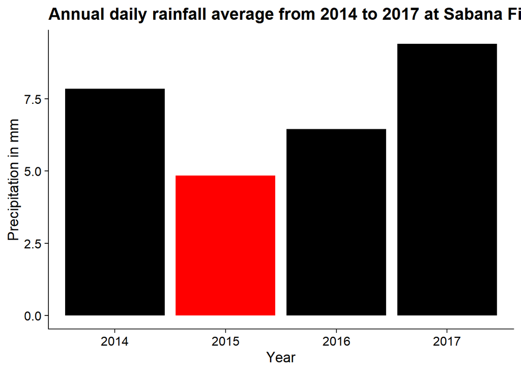

#### Discussion

This bar graph highlights the severe impact of droughts on daily average amount of precipitation in Sabana Field Research Station in 2015. It’s necessary to note that we chose to plot out the daily rainfall average due to the inconsistent of our meterological data (missing data for days, shortage of electricity)

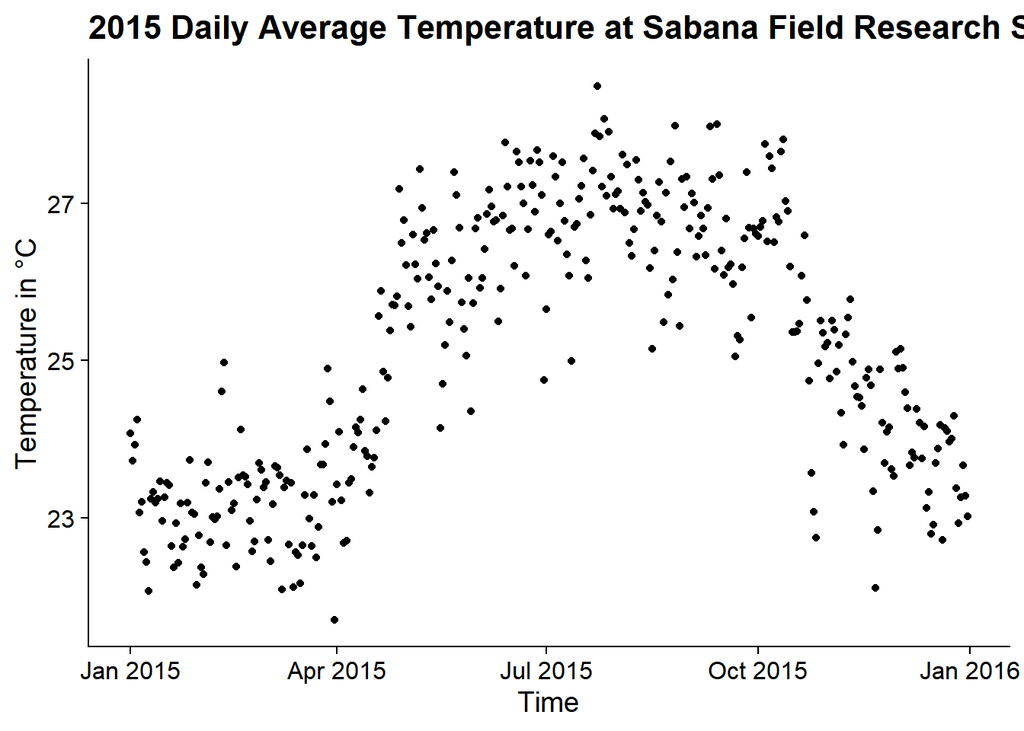

#### Discussion

Delving into the trend of daily temperature in Sabana Field Research Station in 2015, we notice a temperature spike from May to early November. This immense changes clearly demonstrate the impact of the major drought on Luquillo Mountains’ daily temperature.

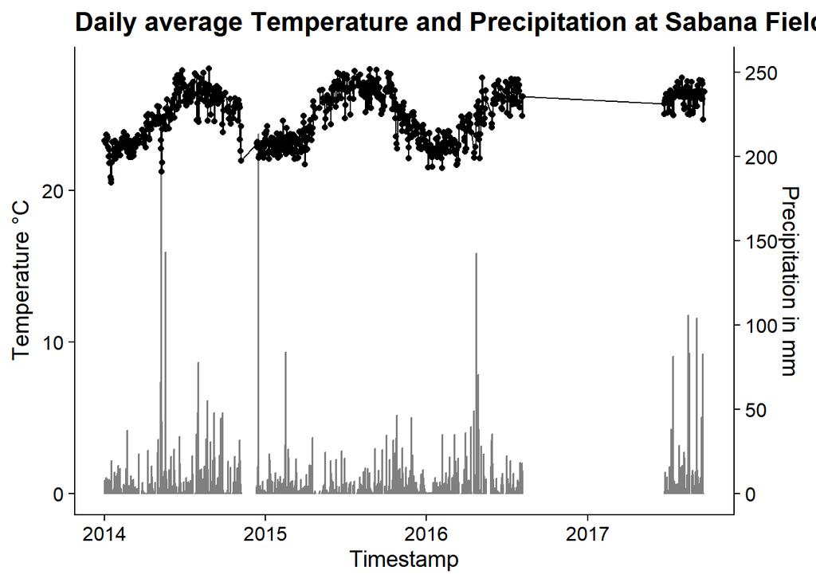

#### Discussion

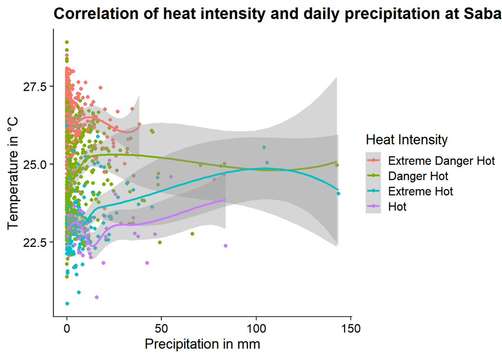

#### Discussion

According to CDC heat index chart, there is a total of five stages of heat intensity in descending order: Extreme Danger Hot, Danger Hot, Extreme Hot, Hot, and Normal. Even though the data points are quite variable for Danger Hot and Extreme Hot days, there is an association between temperature and precipitation in the most heat intense days. This observation supports our hypothesis of the positive correlation between low rainfall and high heat shock. Yet, we need to further test the statistical significance of this relationship.

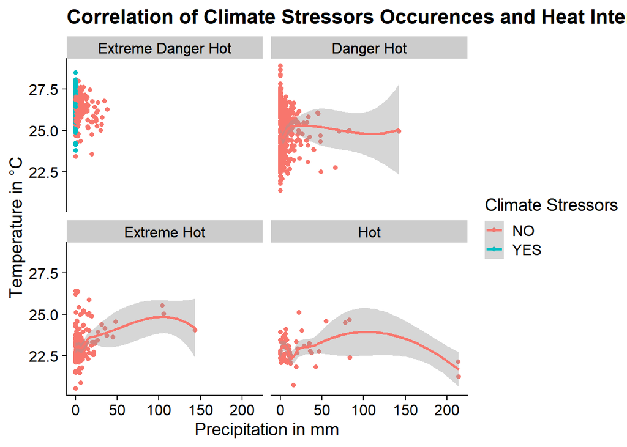

#### Discussion

“Climate Stressors” variable (days with low rainfall and intense heat shock) is introduced to further investigate the relationship between daily temperature and rainfall in Sabana Field Research Station. Zooming in the subset of Extreme Danger Hot days, we notice all “Climate Stressors” days appear here, associating with 0 mm of daily precipitation.

### Bisley Experimental Watersheds

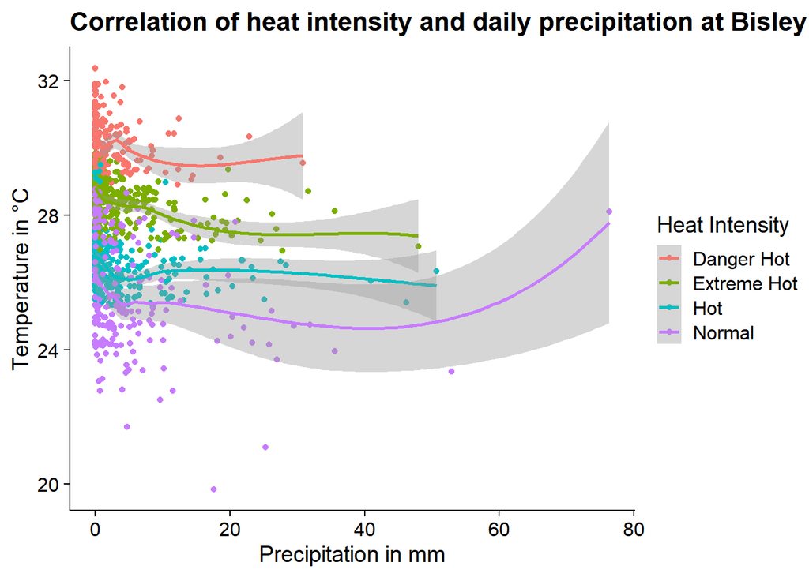

#### Discussion

This graph captures the correlation of heat intensity (from daily maximum temperature) and daily precipitation at Bisley Experimental Watersheds. With the higher elevation above the sea level, the daily heat of Bisley tends to be more mild compared to Sabana’s. However, similar to Sabana Field Research Station, despite the variability of data points for Extreme Hot and Hot days in Bisley, there is an association between temperature and precipitation in the most heat intense day, supporting our first hypothesis.

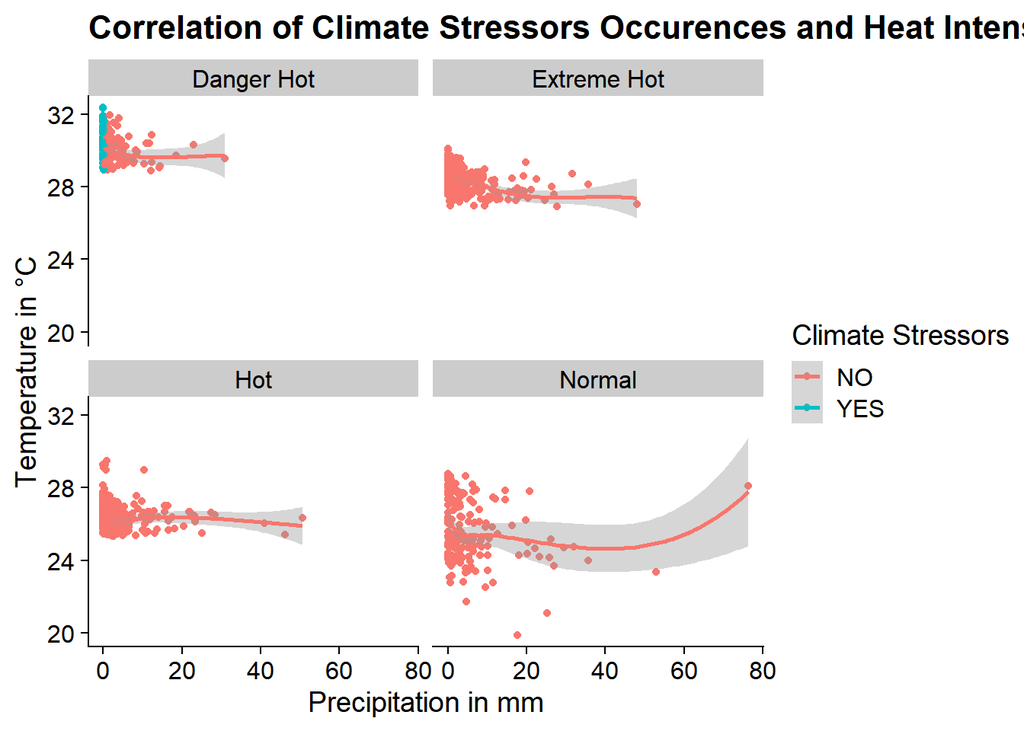

### Sabana Field Research Station vs. Bisley Experimental Watersheds

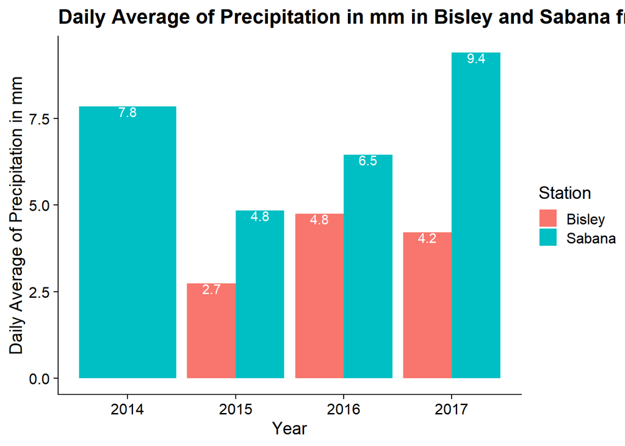

#### Discussion

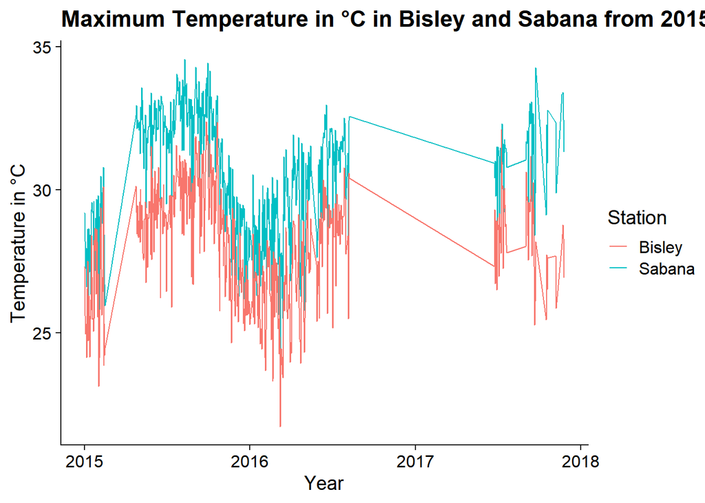

#### Discussion

```r
model <- lm(weatherTRACE$`TOT_PREP(mm)`~ AirTC_Max + weatherTRACE$heatStatus + weatherTRACE$rainfallStatus, data = weatherTRACE)
summary(model)
```

```
##
## Call:
## lm(formula = weatherTRACE$`TOT_PREP(mm)` ~ AirTC_Max + weatherTRACE$heatStatus +
##     weatherTRACE$rainfallStatus, data = weatherTRACE)
##
## Residuals:
##     Min      1Q  Median      3Q     Max
## -26.594  -6.020  -2.161   2.144 180.428
##
## Coefficients:
##                                         Estimate Std. Error t value Pr(>|t|)
## (Intercept)                             119.1937    19.5095   6.110 1.43e-09
## AirTC_Max                                -3.4974     0.6042  -5.788 9.52e-09
## weatherTRACE$heatStatusDanger Hot        -5.4187     1.6592  -3.266  0.00113
## weatherTRACE$heatStatusExtreme Hot      -11.6811     2.9072  -4.018 6.31e-05
## weatherTRACE$heatStatusHot               -4.9472     4.2468  -1.165  0.24433
## weatherTRACE$rainfallStatusLow rainfall  -6.0286     1.0919  -5.521 4.29e-08
##
## (Intercept)                             ***
## AirTC_Max                               ***
## weatherTRACE$heatStatusDanger Hot       **
## weatherTRACE$heatStatusExtreme Hot      ***
## weatherTRACE$heatStatusHot
## weatherTRACE$rainfallStatusLow rainfall ***
## ---
## Signif. codes:  0 '***' 0.001 '**' 0.01 '*' 0.05 '.' 0.1 ' ' 1
##
## Residual standard error: 14.59 on 1002 degrees of freedom
## Multiple R-squared:  0.1502, Adjusted R-squared:  0.1459
## F-statistic: 35.42 on 5 and 1002 DF,  p-value: < 2.2e-16
```

```r
model1 <- lm(weatherBisley$`TOT_PREP(mm)`~ AirTC_Max + weatherBisley$heatStatus + weatherBisley$rainfallStatus , data = weatherBisley)
summary(model1)
```

```
##
## Call:
## lm(formula = weatherBisley$`TOT_PREP(mm)` ~ AirTC_Max + weatherBisley$heatStatus +
##     weatherBisley$rainfallStatus, data = weatherBisley)
##
## Residuals:
##    Min     1Q Median     3Q    Max
## -8.588 -3.430 -1.024  0.739 72.500
##
## Coefficients:
##                                          Estimate Std. Error t value Pr(>|t|)
## (Intercept)                               62.8532     9.4205   6.672 4.22e-11
## AirTC_Max                                 -1.0297     0.2166  -4.754 2.30e-06
## weatherBisley$heatStatusDanger Hot       -27.6877     6.3914  -4.332 1.63e-05
## weatherBisley$heatStatusExtreme Hot      -28.6342     6.4190  -4.461 9.11e-06
## weatherBisley$heatStatusHot              -30.4349     6.4889  -4.690 3.12e-06
## weatherBisley$heatStatusNormal           -30.1191     6.5307  -4.612 4.52e-06
## weatherBisley$rainfallStatusLow rainfall  -4.4675     0.4839  -9.233  < 2e-16
##
## (Intercept)                              ***
## AirTC_Max                                ***
## weatherBisley$heatStatusDanger Hot       ***
## weatherBisley$heatStatusExtreme Hot      ***
## weatherBisley$heatStatusHot              ***
## weatherBisley$heatStatusNormal           ***
## weatherBisley$rainfallStatusLow rainfall ***
## ---
## Signif. codes:  0 '***' 0.001 '**' 0.01 '*' 0.05 '.' 0.1 ' ' 1
##
## Residual standard error: 6.356 on 976 degrees of freedom
## Multiple R-squared:  0.1557, Adjusted R-squared:  0.1505
## F-statistic:    30 on 6 and 976 DF,  p-value: < 2.2e-16
```

#### Models Interpretation

```r
weatherTRACE <- weatherTRACE %>% mutate("Climate Stressors" = ifelse(heatStatus == "Extreme Danger Hot"  & rainfallStatus == "Low rainfall", 1, 0), Station = "TRACE")

weatherBisley <- weatherBisley %>% mutate("Climate Stressors" = ifelse(heatStatus == "Extreme Danger Hot" | heatStatus == "Danger Hot" & rainfallStatus == "Low rainfall", 1, 0), Station = "Bisley")
colnames(weatherBisley)[5] <- "Relative Humidity"

weatherAll <- rbind(weatherTRACE %>% select(- c(AirTC_Avg, total_Precip_month, total_Precip_year)), weatherBisley %>% select(-c(AirTC_Min, RH_Min)))

model4 <- lm(weatherAll$`TOT_PREP(mm)` ~ AirTC_Max + weatherAll$heatIndex + weatherAll$rainfallStatus + weatherAll$Station, data = weatherAll)
summary(model4)
```

```
##
## Call:
## lm(formula = weatherAll$`TOT_PREP(mm)` ~ AirTC_Max + weatherAll$heatIndex +
##     weatherAll$rainfallStatus + weatherAll$Station, data = weatherAll)
##
## Residuals:
##     Min      1Q  Median      3Q     Max
## -13.889  -4.954  -1.753   1.582 195.042
##
## Coefficients:
##                                       Estimate Std. Error t value Pr(>|t|)
## (Intercept)                           52.35545    6.64930   7.874 5.61e-15 ***
## AirTC_Max                             -2.10245    0.41888  -5.019 5.65e-07 ***
## weatherAll$heatIndex                   0.12289    0.05973   2.057   0.0398 *
## weatherAll$rainfallStatusLow rainfall -5.50563    0.61434  -8.962  < 2e-16 ***
## weatherAll$StationTRACE                5.56086    0.71991   7.724 1.77e-14 ***
## ---
## Signif. codes:  0 '***' 0.001 '**' 0.01 '*' 0.05 '.' 0.1 ' ' 1
##
## Residual standard error: 11.54 on 1986 degrees of freedom
## Multiple R-squared:  0.1214, Adjusted R-squared:  0.1196
## F-statistic: 68.58 on 4 and 1986 DF,  p-value: < 2.2e-16
```

#### Model Intepretation

Meteorological data from two sites are merged together. We then fit the data into a linear regression model. With an increase in one Celsius degree, there would be a decrease of 2.1mm in precipitation that day. Statistically, this model has statistical significant p-values (< 2.2e-16) though insignificant R-squared (~0.12)

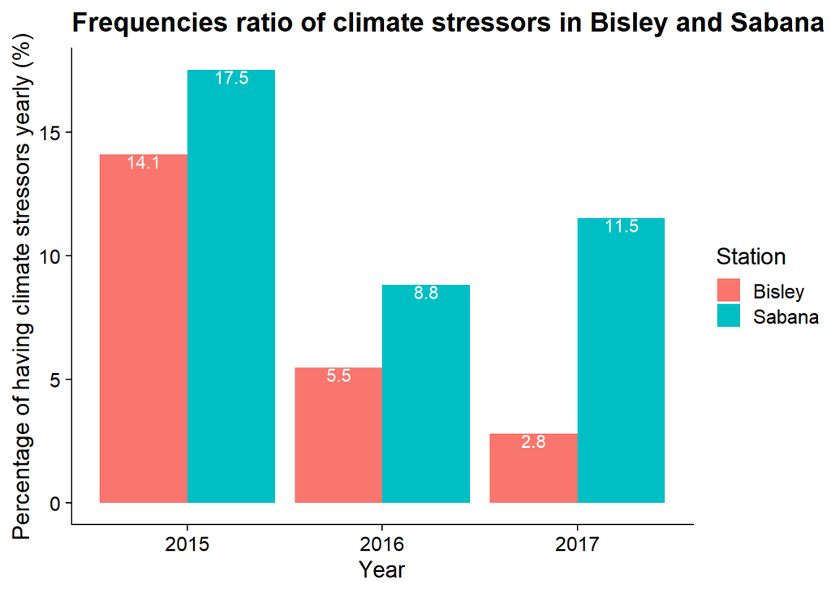

#### Discussion

From 2015 to 2017, the percentage of having a climate-stressors day of TRACE is always higher than Bisley’s, suggesting that TRACE will be likely to experience low rainfall and high heat shock compared to Bisley.

### Seedling and Sapling Census

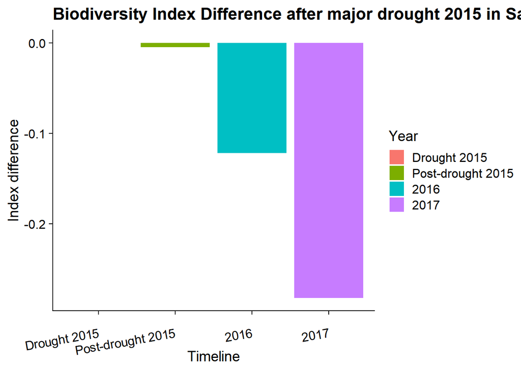

#### Discussion

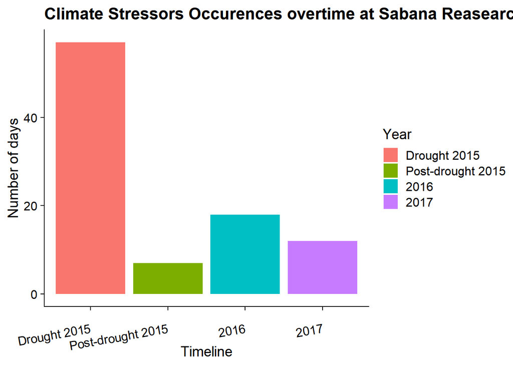

#### Discussion

```r
climatestressorsbyStation <- weatherAll %>% mutate(yearR = case_when(year != 2015 ~ as.character(year),
                                          year == 2015 & month %in% c("January", "February", "March", "April") ~ "Pre-drought 2015",
                                          year == 2015 & month %in% c("May", "June", "July", "August", "September", "October") ~ "Drought 2015",
                                          year == 2015 & month %in% c("November", "December") ~ "Post-drought 2015")) %>%
                filter(`Climate Stressors` == 1) %>% group_by(yearR, Station)  %>%  count() %>% filter(yearR != 2014)

res.aov <- aov(n ~ Station, data = climatestressorsbyStation)
summary(res.aov)
```

```
##             Df Sum Sq Mean Sq F value Pr(>F)
## Station      1      0     0.0       0  0.992
## Residuals    5   2122   424.3
```

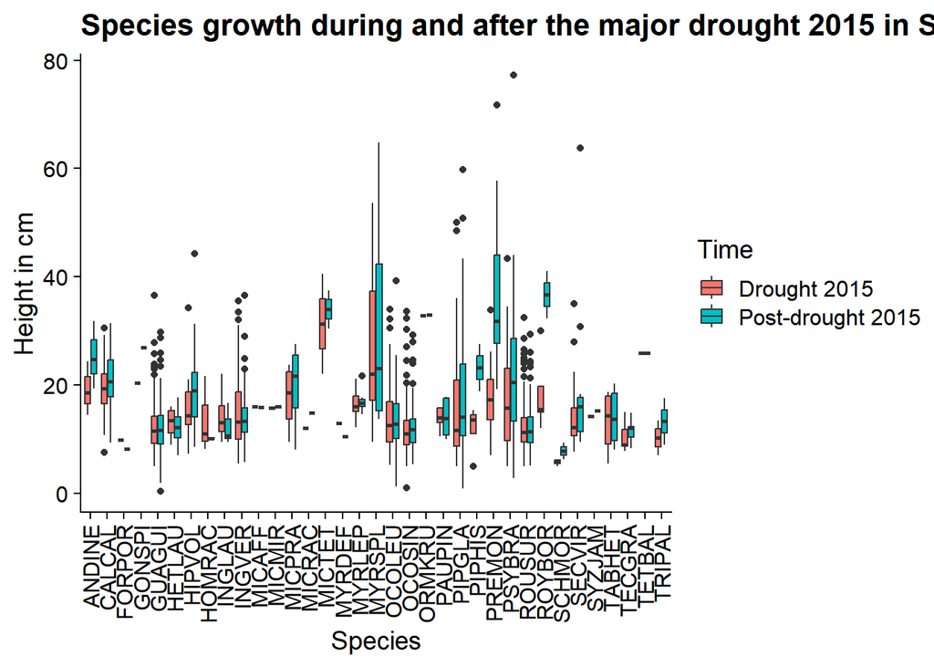

#### Discussion

This visualize investigate the changes in heights of all species that got recorded in Sabana Field Research Station during and after drought. We can notice some of the good drought-resistance species in this forest, including PREMON, PIPHIS, or ROYBOR. We were then eager to capture the species’ percent of growth after the major drought.

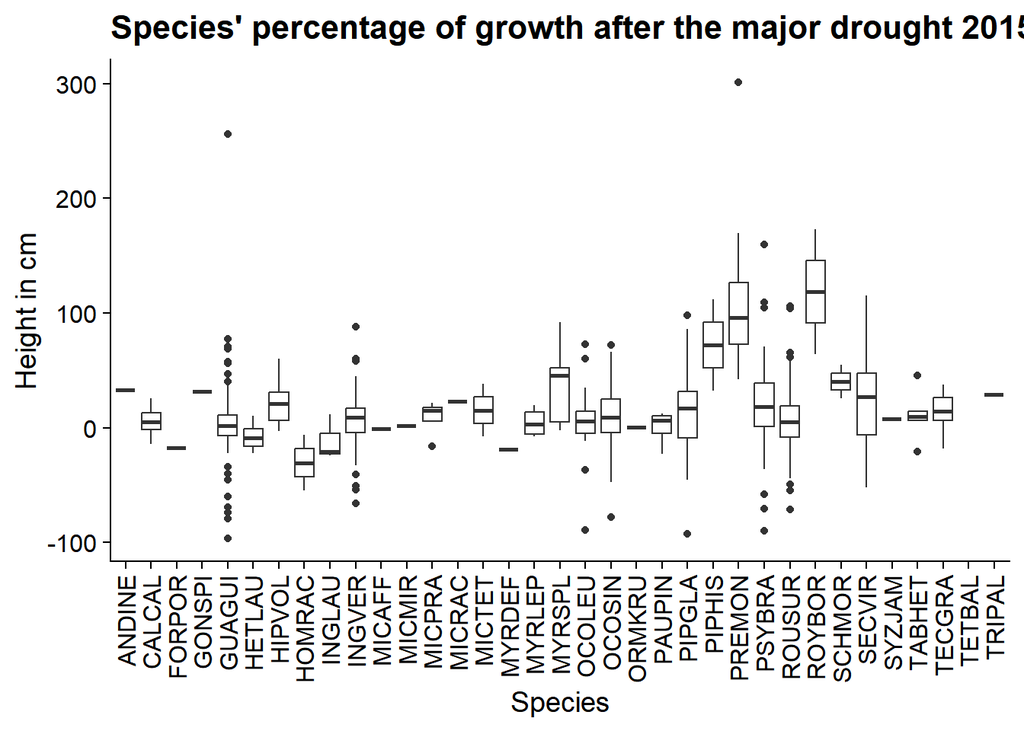

#### Discussion

Similar to previous visualization, PREMON, PIPHIS, and ROYBOR are standing out to be one of the best drought-resistance species in this forest. This might suggest residents near Luquillo Mountains to grow them to avoid land fragment during severe drought in the future.

```
## # A tibble: 3 × 2
##    year     x
##   <int> <dbl>
## 1  2015  815.
## 2  2016 1734.
## 3  2017 1346
```

```
## [1] 1587.2
```

```
## # A tibble: 4 × 2
## # Groups:   year [4]
##    year total_Precip_year
##   <dbl>             <dbl>
## 1  2014             2625.
## 2  2015             1767.
## 3  2016             1316.
## 4  2017              978.
```